**Machine Learning VS Deep Learning**

Autors :

```
    - MOHAMED ALIMOUSSA
    - AMAL EL KAID
```

# 1. MOTIVATION :

Is Deep Learning always a better solution then Machine Learning in solving all problems ? with the fact that Deep Learning takes more time, makes more complexe calculations and needs more powerful machines then ML

In this notebook, we will take a problem that ML knows better and try to apply them both and see which one would be better in this particular problem

Since we are always talking about image classification, our DL model will take all the images as input but for ML it doesn't work like that, in fact we will have to to exctract a certain feature from the images and give it as input to the ML model.

**What problem are we talking about ?**

We have tried to find a problem where machine learning seem to solve easly to see if DL would act better in such problems. In fact we have chosen to classify images to 3 classes: Nature, Desert and Sea.

**Why would the problem be easy for ML ?**

If we payed attetion to our 3 classes, we will find tahat we have chosen them wisely, moreover we can easly classify between the 3 classes using only a **color discriptor** whish is an easy thing for ML. but what is DL gonna do ? taking more unusful discriptors as texture and shapes ???

**Which discriptor ?**

Since the chose of the discriptor is the most important thing in the built of a ML model, we have as we said urlier tried to chose a problem where the discriptor will be something easy for ML, the most powerful discriptor for ML is Color discriptor more particulary **color histogramme**.

Note : as we said before, it is always wrong to specify for DL a discriptor as it takes all the images as input and tries to build and generate a sum of discriptor by its own.

First Let's import the needed libraries

```python
import tensorflow as tf
from skimage import data
import matplotlib.pyplot as plt
import os
import random
from skimage import transform
import numpy as np
from PIL import Image
from tensorflow.contrib.layers import flatten
from shuf import shuffle_same_way
```

# 2. PREPARING THE DATA :

First Step is data preparing, as we said we will do a image classification and the 3 chosen classes are images of Nature, Desert and Sea, in this phase we will :

```
- Download the images for each class using google image and a navigator add's on
- Pre-processing image : Reseizing and cleaning.
- Load the data to an array to make the calculation.
```

After downloading our data, we have 2 ways of handling it all have the same result is to get an array of all images of same size, to explain more we will discust these 2 ways

```
- FIRST WAY : is to clean our images from unwanted images and then load them to an array then applying the resize function ( as seen in preivous labs)
- SECONDE WAY : is to first make a resize to of our images after the cleaning of cours, then directory load our resized data.
```

In the rest of this lab we will use the seconde way, because of the load function that takes too much time dealing with big images and loading them to an array and for the fact that the seconde way keeps a trace of our execution (a resized data saved!).

### 2.1. Download our images :

There is many ways to create an own datasat, here we have chosen to scrap from google images a class images using an add's on : Google Image Downloader

[figure not shown]

### 2.2. Resizing and Cleaning images :

Before we start working with our images, we will have to clean them first then making a standart size to make it easing for the calculations.

**2.2.1. Cleaning :**  
As we have scrapt images from a web engine, not every image represent what is wannted for example, the the figure below the nature image doesn't presente a nature view, it will dammage our model. Cleaning is a very important phase in our preparation of data.

[figure not shown]

**2.2.2. Resizing images :** Handling images of different sizes?

To do so, we will create a new dataset containing all the image in a certain size, to make it easy to load them next time.

```python
#Creating the new data directories :
#For the main folder :
os.makedirs("/home/mohamed/Documents/Others/deep_learning/Seconde_Lab2/Data40")

#For Training :
os.makedirs("/home/mohamed/Documents/Others/deep_learning/Seconde_Lab2/Data40/Training")
os.makedirs("/home/mohamed/Documents/Others/deep_learning/Seconde_Lab2/Data40/Training/0")
os.makedirs("/home/mohamed/Documents/Others/deep_learning/Seconde_Lab2/Data40/Training/1")
os.makedirs("/home/mohamed/Documents/Others/deep_learning/Seconde_Lab2/Data40/Training/2")

#For Testing
os.makedirs("/home/mohamed/Documents/Others/deep_learning/Seconde_Lab2/Data40/Testing")
os.makedirs("/home/mohamed/Documents/Others/deep_learning/Seconde_Lab2/Data40/Testing/0")
os.makedirs("/home/mohamed/Documents/Others/deep_learning/Seconde_Lab2/Data40/Testing/1")
os.makedirs("/home/mohamed/Documents/Others/deep_learning/Seconde_Lab2/Data40/Testing/2")
```

**resize_and_save**

A function that takes all images from each sub directory, resize them, and store them in the created direcotries above.

```python
def resize_and_save(data_dir,new_dir):
    #Getting data

    i = 0
    file_names = [os.path.join(data_dir, f) for f in os.listdir(data_dir)]

    for f in file_names:
        i = i + 1

        basewidth = 40
        baseheight= 40
        img = Image.open(f)
        a = (basewidth/float(img.size[0]))
        b = (baseheight/float(img.size[1]))

        img = img.resize((basewidth,baseheight), Image.ANTIALIAS)
        image_name = new_dir+ str(i) + ".png"
        img.save(image_name)
```

For the First class : The Nature images

```python
# Resizing the images in nature and storing the result in Nature40

# For Training : FROM -- TO
NatureT = "/home/mohamed/Documents/Others/deep_learning/Seconde_Lab2/Data/Training/0"
Nature40T = "/home/mohamed/Documents/Others/deep_learning/Seconde_Lab2/Data40/Training/0/"

#For Testing : FROM -- TO
NatureTe = "/home/mohamed/Documents/Others/deep_learning/Seconde_Lab2/Data/Testing/0"
Nature40Te = "/home/mohamed/Documents/Others/deep_learning/Seconde_Lab2/Data40/Testing/0/"

resize_and_save(NatureT,Nature40T)
resize_and_save(NatureTe,Nature40Te)
```

For the Seconde class : The Desert images

```python
#Resizing the images in nature and storing the result in Nature40
#For Training : FROM -- TO
DesertT = "/home/mohamed/Documents/Others/deep_learning/Seconde_Lab2/Data/Training/2"
Desert40T = "/home/mohamed/Documents/Others/deep_learning/Seconde_Lab2/Data40/Training/1/"

#For Testing : FROM -- TO
DesertTe = "/home/mohamed/Documents/Others/deep_learning/Seconde_Lab2/Data/Testing/2"
Desert40Te = "/home/mohamed/Documents/Others/deep_learning/Seconde_Lab2/Data40/Testing/1/"

resize_and_save(DesertT,Desert40T)
resize_and_save(DesertTe,Desert40Te)
```

For the Third class : The Sea images

```python
#Resizing the images in nature and storing the result in Nature40
#For Training : FROM -- TO
SeaT = "/home/mohamed/Documents/Others/deep_learning/Seconde_Lab2/Data/Training/3"
Sea40T = "/home/mohamed/Documents/Others/deep_learning/Seconde_Lab2/Data40/Training/2/"

#For Testing : FROM -- TO
SeaTe = "/home/mohamed/Documents/Others/deep_learning/Seconde_Lab2/Data/Testing/3"
Sea40Te = "/home/mohamed/Documents/Others/deep_learning/Seconde_Lab2/Data40/Testing/2/"

resize_and_save(SeaT,Sea40T)
resize_and_save(SeaTe,Sea40Te)
```

```python
resize_and_save("/home/mohamed/Documents/Others/deep_learning/Seconde_Lab2/testData/Testing/2","/home/mohamed/Documents/Others/deep_learning/Seconde_Lab2/testData40/Testing/2")
```

### 2.3. Loading our Data :

**Load_data** :

A function that takes all images from each sub directory and turn them to a list, for each sub directory the function stockes the label (number of images in sub folder) time, so each image will have the corresponding label. the function uses OS library whish is a directory and files manager.

We will use this function on the resized data: Data40.

```python
Training_dir = "/home/mohamed/Documents/Others/deep_learning/Seconde_Lab2/Data40/Training"
Testing_dir  = "/home/mohamed/Documents/Others/deep_learning/Seconde_Lab2/Data40/Testing"
```

```python
def load_data(data_dir):
    # Get all subdirectories of data_dir. Each represents a label.
    directories = [d for d in os.listdir(data_dir)
                   if os.path.isdir(os.path.join(data_dir, d))]
    # Loop through the label directories and collect the data in
    # two lists, labels and images.
    labels = []
    images = []
    for d in directories:
        label_dir = os.path.join(data_dir, d)
        file_names = [os.path.join(label_dir, f)
                      for f in os.listdir(label_dir)]
        for f in file_names:
            images.append(data.imread(f))
            labels.append(int(d))
    return images, labels
```

```python
# Loading our Train images and labels
image_train,Label_train = load_data(Training_dir)
```

```python
# Loading our Test images and labels
image_test,Label_test = load_data(Testing_dir)
```

After the **image processing phase** we have got as a result :

```
- Image_train : an array that contains all the Train images resized.
- Label_train : an array containing the Training labels.
- Image_test  : an array that contains all the Test images resized.
- Label_train : an array containing the Testing labels.
```

## 3. EXPLOTE THE DATA :

How many images and labels do we have?

```python
print("In Training data : \t"+str(len(image_train)))
print("In Testing data : \t"+str(len(image_test)))
```

```
In Training data : 	228
In Testing data : 	48
```

```python
print("The size of our images is : "+str(image_train[0].shape))
```

```
The size of our images is : (40, 40, 3)
```

The function used in the previous lab. This function takes as an argument the array of images and their labels and plot them.

```python
def display_images_and_labels(images, labels,n):
    """Display the first image of each label."""
    how_many = random.sample([e for e in range(len(images))],n)

    plt.figure(figsize=(15, 15))
    i = 1
    for index in how_many:
        # Pick the first image for each label.
        image = images[index]
        plt.subplot(7, 7, i)  # A grid of 8 rows x 8 columns
        plt.axis('off')
        if(labels[index] == 0):
                var = "Nature"
        else:
            if(labels[index] == 1):
                    var = "Desert"
            else:
                    var = "Sea"

        plt.title("Label : {0}".format(var))
        i += 1
        plt.imshow(image)

    plt.show()
```

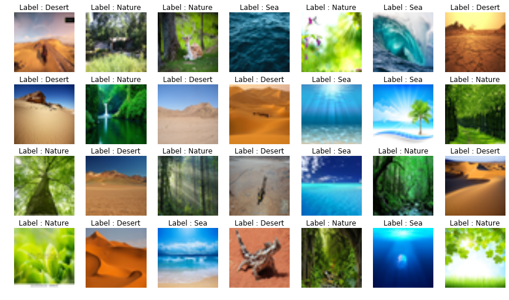

```python
display_images_and_labels(image_train[:], Label_train[:],28)
```

# 4. DEEP LEARNING : CNN MODEL :

## 4.1 ALEXNET CNN MODEL

Three steps to create a CNN

1. Convolution
2. Activation
3. Pooling Repeat Steps 1,2,3 for adding more hidden layers
4. After that make a fully connected network This fully connected network gives ability to the CNN to classify the samples

for ALEXNET CNN Model we will be using this architecture :

```python
def create_conv_model(input_data):
    input_layer = tf.reshape(input_data, [-1,40,40,3])
	#input_layer= tf.contrib.layers.flatten(input_layer)

	##First Convolutional Layer and pooling layer
    conv1 = tf.layers.conv2d(inputs = input_layer,filters =96,kernel_size =[11,11],padding ="same",activation = tf.nn.relu)
    pool1 = tf.layers.max_pooling2d(inputs=conv1, pool_size=[3, 3], strides= 2)

	## Second Convolutional Layer and pooling layer

    conv2 = tf.layers.conv2d(inputs = pool1,filters =128,kernel_size =[5,5],padding ="same",activation = tf.nn.relu)
    pool2 = tf.layers.max_pooling2d(inputs=conv2, pool_size=[3, 3], strides =2)

	## Third Convolutional Layer and pooling layer
    conv3 = tf.layers.conv2d(inputs = input_layer,filters =384,kernel_size =[3,3],padding ="same",activation = tf.nn.relu)
    pool3 = tf.layers.max_pooling2d(inputs=conv1, pool_size=[3, 3], strides =2)

	## Fourth Convolutional Layer and pooling layer
    conv4 = tf.layers.conv2d(inputs = input_layer,filters =192,kernel_size =[3,3],padding ="same",activation = tf.nn.relu)
    pool4 = tf.layers.max_pooling2d(inputs=conv1, pool_size=[3, 3], strides =2)

	## Fifth Convolutional Layer and pooling layer
    conv5 = tf.layers.conv2d(inputs = input_layer,filters =128,kernel_size =[3,3],padding ="same",activation = tf.nn.relu)
    pool5 = tf.layers.max_pooling2d(inputs=conv1, pool_size=[2, 2], strides =2)
    pool5_flat = flatten(pool5)

	## First Dense layer
    logit1 = tf.layers.dense(inputs = pool5_flat, units =4096, activation=tf.nn.relu)
	## Second Dense layer

    logit2 = tf.layers.dense(inputs = logit1, units =4096, activation=tf.nn.relu)
	## Third Dense layer
    logit3 = tf.layers.dense(inputs = logit2, units = 3)

    return logit3
```

```python
#declare the inputs x and calculated output y as placeholders according to
x = tf.placeholder(dtype = tf.float32, shape =[None, 40, 40, 3],name="data")
y = tf.placeholder(dtype = tf.int32, shape = [None],name="label")
```

Here we won't be creating any weight variable, in fact, **create_conv_model creates a variable called weights and saves it in the session** that we will be creating, representing a fully connected weight matrix.

```python
 # Call the model function
alex_logits = create_conv_model(x)

#define loss and optimizer

loss = tf.reduce_mean(tf.nn.sparse_softmax_cross_entropy_with_logits(labels = y, logits = alex_logits))
train = tf.train.AdamOptimizer(learning_rate=0.001).minimize(loss)
```

```python
correct_pred = tf.argmax(alex_logits, 1)
```

Transforme the data and labels to an array to make the training.

```python
image_train = np.array(image_train,dtype=float)
image_test = np.array(image_test,dtype=float)

Label_train = np.array(Label_train,dtype=int)
Label_test = np.array(Label_test,dtype=int)
```

```python
for i in range(len(image_test)):
    if(image_test[i].shape[2] == 4):
        del image_test[i]
        del Label_test[i]
```

## 4.2 TRAINING PHASE :

```python
# Create a session
sess = tf.Session()
```

```python
sess.run(tf.global_variables_initializer())
```

```python
loss_his = []

image_train,Label_train = shuffle_same_way(image_train,Label_train)

for i in range(30):
    _, loss_val = sess.run([train , loss], feed_dict={x: image_train,y: (Label_train)})

    print("EPOCH "+str(i)+"        Loss: "+str(loss_val))
    loss_his.append(loss_val)
```

```
EPOCH 0        Loss: 10.6924
EPOCH 1        Loss: 13942.8
EPOCH 2        Loss: 3738.29
EPOCH 3        Loss: 3206.3
EPOCH 4        Loss: 1898.7
EPOCH 5        Loss: 1731.57
EPOCH 6        Loss: 205.779
EPOCH 7        Loss: 91.1788
EPOCH 8        Loss: 42.7376
EPOCH 9        Loss: 20.2537
EPOCH 10        Loss: 9.30173
EPOCH 11        Loss: 9.3007
EPOCH 12        Loss: 8.35587
EPOCH 13        Loss: 5.68341
EPOCH 14        Loss: 2.84853
EPOCH 15        Loss: 1.17694
EPOCH 16        Loss: 0.438626
EPOCH 17        Loss: 0.753135
EPOCH 18        Loss: 1.01851
EPOCH 19        Loss: 0.905331
EPOCH 20        Loss: 0.637383
EPOCH 21        Loss: 0.4324
EPOCH 22        Loss: 0.318633
EPOCH 23        Loss: 0.259145
EPOCH 24        Loss: 0.241226
EPOCH 25        Loss: 0.242759
EPOCH 26        Loss: 0.243535
EPOCH 27        Loss: 0.233119
EPOCH 28        Loss: 0.211915
EPOCH 29        Loss: 0.18803
```

## 4.3 TESTING PHASE :

```python
predicted = sess.run([correct_pred], feed_dict={x: image_test})[0]

accuracy = tf.reduce_sum(tf.cast(tf.equal(correct_pred,Label_test),tf.float32))

print("The accuracy of our model is : "+ str(100*(sess.run(accuracy,feed_dict={x: image_test})/len(Label_test)))[0:6]+" %")
```

```
The accuracy of our model is : 36.956 %
```

# 5. MACHINE LEARNING :

## 5.1 Feature exctraction : Color histogramme

As discusted before in the Machine learning training we will be using color histograms as features, for that we will need to get all color histograms from our data : train_image and test_image defined already

**get_hitogram** : a function that takes as input the data directory and returns all color histograms of the images of that directory. will be using it 2 time, one for testing and the other for training

```python
def get_histogram(data_dir):
    # Get all subdirectories of data_dir. Each represents a label.
    directories = [d for d in os.listdir(data_dir)
                   if os.path.isdir(os.path.join(data_dir, d))]
    # Loop through the label directories and collect the data in
    # two lists, labels and images.
    labels = []
    hist = []
    for d in directories:
        label_dir = os.path.join(data_dir, d)
        file_names = [os.path.join(label_dir, f)
                      for f in os.listdir(label_dir)]
        for f in file_names:
            img = Image.open(f)
            h = img.histogram()
            hist.append(h)
            labels.append(int(d))
    return hist, labels
```

```python
# Color histograms for the Training images
train_images_histograme,train_histogram_labels = get_histogram(Training_dir)
```

```python
# Color histograms for the Testing images
test_images_histograme,test_histogram_labels = get_histogram(Testing_dir)
```

```python
# delete the elemnts that have more then 3 GRIDS : not only RGB
for i in range(0,len(train_histogram_labels)):
    if(len(train_images_histograme[i]) != 768):
        del train_histogram_labels[i]
        del train_images_histograme[i]

for i in range(0,len(test_images_histograme)):
    if(len(test_images_histograme[i]) != 768):
        del test_histogram_labels[i]
        del test_images_histograme[i]
```

[output not shown]

```python
# covnert the Y to a 3 dimmentional array that contain the exact class : (1,0,0) means the first class for example
ML_labels = []
for i in range(len(train_histogram_labels)):
    if(train_histogram_labels[i]==0):
            ML_labels.append([1,0,0])
    else:
        if(train_histogram_labels[i]==1):
            ML_labels.append([0,1,0])
        else:
            if(train_histogram_labels[i]==2):
                ML_labels.append([0,0,1])
```

```python
# covnert the Y to a 3 dimmentional array that contain the exact class : (1,0,0) means the first class for example
ML_labels2 = []
for i in range(0,len(test_histogram_labels)):
    if(test_histogram_labels[i]==0):
        ML_labels2.append([1,0,0])
    else:
        if(test_histogram_labels[i]==1):
            ML_labels2.append([0,1,0])
        else:
            if(test_histogram_labels[i]==2):
                ML_labels2.append([0,0,1])
```

## 5.2 TRAINING PHASE :

```python
# Define parameters for linear model
learning_rate = 0.1
n_epochs = 200
batch_size = 5
n_batches = len(train_images_histograme)/batch_size

batch_size2=10
n_batches2 = len(test_histogram_labels)/batch_size2
```

```python
# Create placeholders
X = tf.placeholder(tf.float32, [None,768])
Y = tf.placeholder(tf.float32, [None, 3], name="label")

# Create weights and bias
w = tf.Variable(tf.random_normal(shape=[768, 3], stddev=0.01), name="weights")
b = tf.Variable(tf.zeros([1,3]), name='bias')
```

```python
# calculate scores
ML_logits = tf.matmul(X, w) + b

# Entropy cost function and loss
entropy = tf.square(ML_logits - Y )
ML_loss = tf.reduce_mean(entropy)

# Define optimizer(logits = yPredbyNN, labels=Y)
ML_optimizer = tf.train.AdadeltaOptimizer(learning_rate=learning_rate).minimize(ML_loss)
```

```python
loss_history = []
acc_history = []
init = tf.global_variables_initializer()
```

```python
import random

train_model_his = []

train_images_histograme,ML_labels = shuffle_same_way(train_images_histograme,ML_labels)

with tf.Session() as sess:
    sess.run(init)

    for i in range(200):
        for j in range(0,int(n_batches)):
            X_batch = train_images_histograme[j*batch_size:(j+1)*batch_size]
            Y_batch = ML_labels[j*batch_size:(j+1)*batch_size]

            _, ML_loss_value = sess.run([ML_optimizer, ML_loss], feed_dict={X: X_batch, Y:Y_batch})

        loss_history.append(ML_loss_value)
    print(ML_loss_value)
```

```
0.0261148
```

## 5.3 TESTING PHASE :

```python
plt.plot(loss_history, '-o', label='Loss value')
plt.title('Training Loss')
plt.xlabel('Epoch')
plt.ylabel('Loss Value')
plt.legend(ncol=2, loc='upper right')

plt.gcf().set_size_inches(10, 5)
plt.show()
```

[output not shown]

```python
# Test the Model

accuracies = []
with tf.Session() as sess:
        sess.run(init)
        total_correct_preds = 0
        while(total_correct_preds/len(test_images_histograme)<=0.49):

            total_correct_preds = 0

            test_images_histograme,test_histogram_labels = shuffle_same_way(test_images_histograme,test_histogram_labels)
            logits_batch = sess.run(ML_logits, feed_dict={X: test_images_histograme, Y:ML_labels2})
            #print(logits_batch)
            #print("****")
            preds = tf.nn.softmax(logits_batch)
            #print(sess.run(preds))
        #print(Y_batch)

            correct_preds = tf.equal(tf.argmax(preds, 1), tf.argmax(ML_labels2, 1))
            accuracy = tf.reduce_sum(tf.cast(correct_preds, tf.float32))
            total_correct_preds += sess.run(accuracy)
            acc_history.append((total_correct_preds/len(train_histogram_labels)))
            if(total_correct_preds/len(test_images_histograme)>=0.49):
                print(str(int(total_correct_preds))+" Correct predections of "+str(len(test_histogram_labels)))


        #print(total_correct_preds)
                print("Test accuracy is")
                print(str(total_correct_preds/len(test_histogram_labels)*100)[0:6])
            accuracies.append((total_correct_preds/len(test_histogram_labels))*100)
```

```
24 Correct predections of 46
Test accuracy is
52.173
```

# 6. Conclusion :

**Is the result logical ?**